# ggplot2 数据可视化完全指南

WorkBuddy

2026-08-14

# 1 ggplot2 简介

**ggplot2** 是 R 语言中最流行、最强大的数据可视化包，由 Hadley Wickham 基于 Leland Wilkinson 的著作 *The Grammar of Graphics*（图形语法）开发，是 **tidyverse** 生态系统的核心成员之一。

## 1.1 为什么选择 ggplot2

- **语法一致**：所有图形都由相同的”积木”搭建，学会一个就等于学会全部；
- **层次分明**：可以像搭积木一样，一层一层地叠加图形元素；
- **美观专业**：默认主题和配色已经接近出版级别；
- **高度可定制**：从坐标轴到图例，每个细节都可以调整；
- **生态丰富**：`ggthemes`、`ggrepel`、`patchwork`、`gganimate` 等数百个扩展包。

## 1.2 安装与加载

```r
install.packages("ggplot2")   # 安装（只需一次）
library(ggplot2)              # 加载（每次会话都需要）
```

## 1.3 本文使用的内置数据

ggplot2 和 R 自带了多个示例数据集，本文主要使用：

```r
# 汽车燃油效率数据（ggplot2 内置）
data(mpg)
head(mpg, 3)
```

|  | manufacturer | model | displ | year | cyl | trans | drv | cty | hwy | fl | class |
| --- | --- | --- | --- | --- | --- | --- | --- | --- | --- | --- | --- |
| 1 | audi | a4 | 1.8 | 1999 | 4 | auto(l5) | f | 18 | 29 | p | compact |
| 2 | audi | a4 | 1.8 | 1999 | 4 | manual(m5) | f | 21 | 29 | p | compact |
| 3 | audi | a4 | 2.0 | 2008 | 4 | manual(m6) | f | 20 | 31 | p | compact |

```r
# R 自带的汽车数据
head(mtcars, 3)
```

|  | mpg | cyl | disp | hp | drat | wt | qsec | vs | am | gear | carb |
| --- | --- | --- | --- | --- | --- | --- | --- | --- | --- | --- | --- |
| Mazda RX4 | 21.0 | 6 | 160 | 110 | 3.90 | 2.620 | 16.46 | 0 | 1 | 4 | 4 |
| Mazda RX4 Wag | 21.0 | 6 | 160 | 110 | 3.90 | 2.875 | 17.02 | 0 | 1 | 4 | 4 |
| Datsun 710 | 22.8 | 4 | 108 | 93 | 3.85 | 2.320 | 18.61 | 1 | 1 | 4 | 1 |

# 2 图形语法的核心思想

ggplot2 的灵魂是**图形语法（Grammar of Graphics）**：任何一张统计图形，都可以拆解为若干相互独立的组件（layer，图层），再组合而成。

## 2.1 一张图 = 数据 + 映射 + 几何对象 + ……

| 组件 | 函数 | 作用 |
| --- | --- | --- |
| 数据（Data） | `ggplot(data)` | 绘图所用的数据框 |
| 美学映射（Aesthetics） | `aes()` | 把变量映射到 x、y、颜色、大小、形状等视觉属性 |
| 几何对象（Geom） | `geom_*()` | 决定画什么：点、线、柱、箱线图…… |
| 统计变换（Stat） | `stat_*()` | 对数据进行汇总、平滑等计算 |
| 标度（Scale） | `scale_*()` | 控制映射的细节：颜色方案、坐标轴刻度等 |
| 坐标系（Coord） | `coord_*()` | 笛卡尔坐标、极坐标、翻转坐标等 |
| 分面（Facet） | `facet_*()` | 按变量把图拆成多个子图 |
| 主题（Theme） | `theme_*()` | 字体、背景、网格线等外观 |

## 2.2 基本模板

```r
ggplot(data = <数据>, mapping = aes(<映射>)) +
  <几何对象函数>() +
  <其他图层>()
```

注意：ggplot2 用 **`+` 号**（不是管道 `%>%`）来连接各个图层。

# 3 快速入门：第一张图

以 `mpg` 数据集为例，画出发动机排量（`displ`）与高速油耗（`hwy`）的散点图：

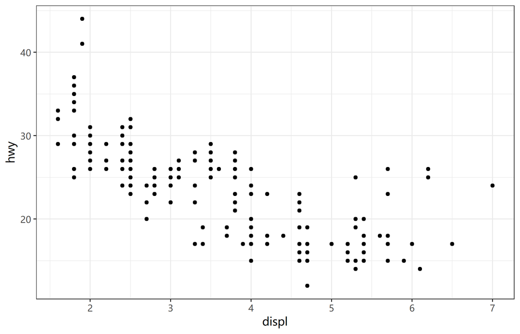

```r
ggplot(data = mpg, mapping = aes(x = displ, y = hwy)) +
  geom_point()
```

**简写形式**：`data =` 和 `mapping =` 可以省略：

```r
ggplot(mpg, aes(displ, hwy)) + geom_point()
```

# 4 美学映射 aes()：用视觉属性表达数据

`aes()` 可以把变量映射到颜色、大小、形状、透明度等视觉通道，这是 ggplot2 与基础绘图最大的不同——**图例会自动生成**。

## 4.1 颜色 color

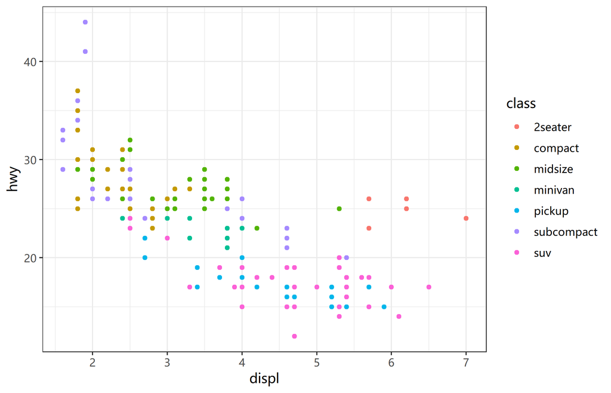

```r
ggplot(mpg, aes(displ, hwy, color = class)) +
  geom_point()
```

## 4.2 大小 size 与透明度 alpha

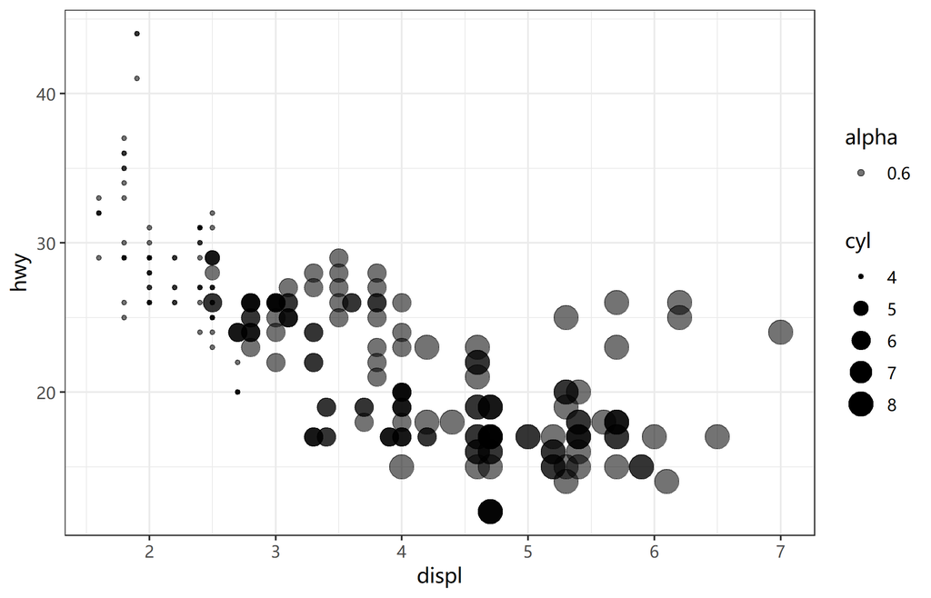

```r
ggplot(mpg, aes(displ, hwy, size = cyl, alpha = 0.6)) +
  geom_point()
```

## 4.3 形状 shape

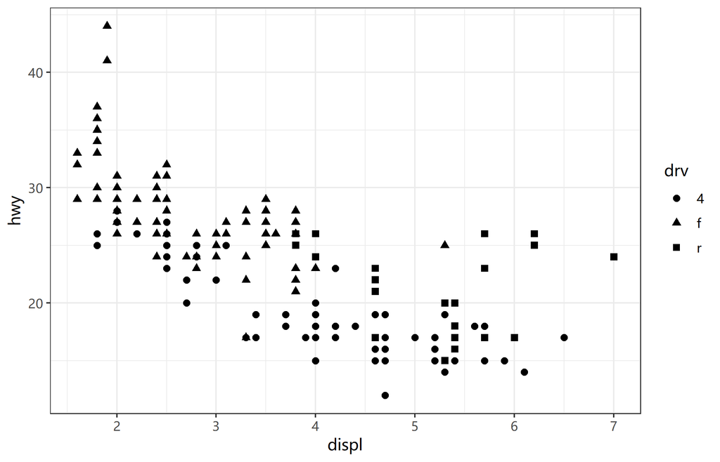

```r
ggplot(mpg, aes(displ, hwy, shape = drv)) +
  geom_point(size = 2)
```

## 4.4 映射 vs 固定值

这是一个常见易错点：**放在 `aes()` 里**是”按变量映射”，**放在 `aes()` 外**是”给所有元素设定固定值”：

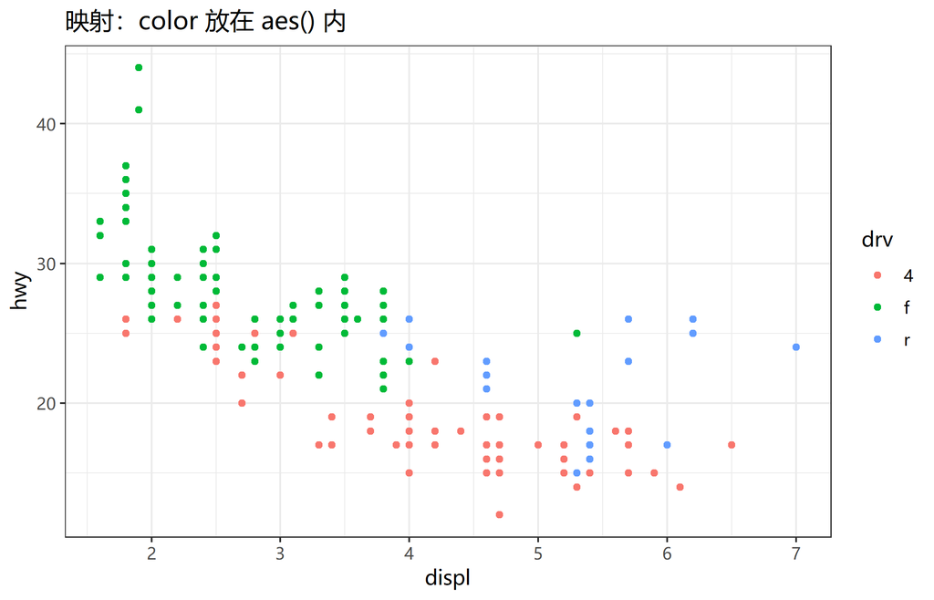

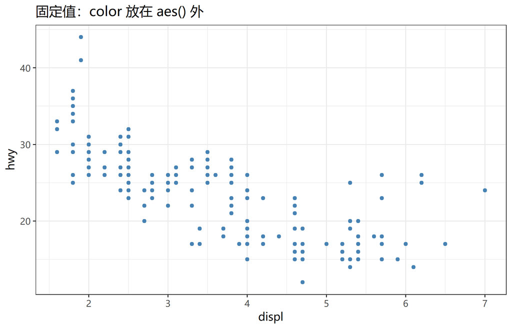

```r
# 按 drv 变量映射颜色（自动生成图例）
ggplot(mpg, aes(displ, hwy, color = drv)) +
  geom_point() +
  labs(title = "映射：color 放在 aes() 内")

# 所有点统一为蓝色（无图例）
ggplot(mpg, aes(displ, hwy)) +
  geom_point(color = "steelblue") +
  labs(title = "固定值：color 放在 aes() 外")
```

# 5 常用几何对象 geom_*

几何对象决定图形的”形状”。常用的有：

## 5.1 散点图 geom_point()

适合展示两个连续变量的关系：

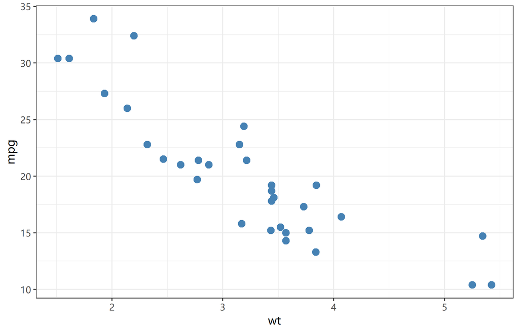

```r
ggplot(mtcars, aes(wt, mpg)) +
  geom_point(color = "steelblue", size = 3)
```

## 5.2 折线图 geom_line() 与路径图 geom_path()

`geom_line()` 按 x 轴顺序连线，适合时间序列；`geom_path()` 按数据原始顺序连线。

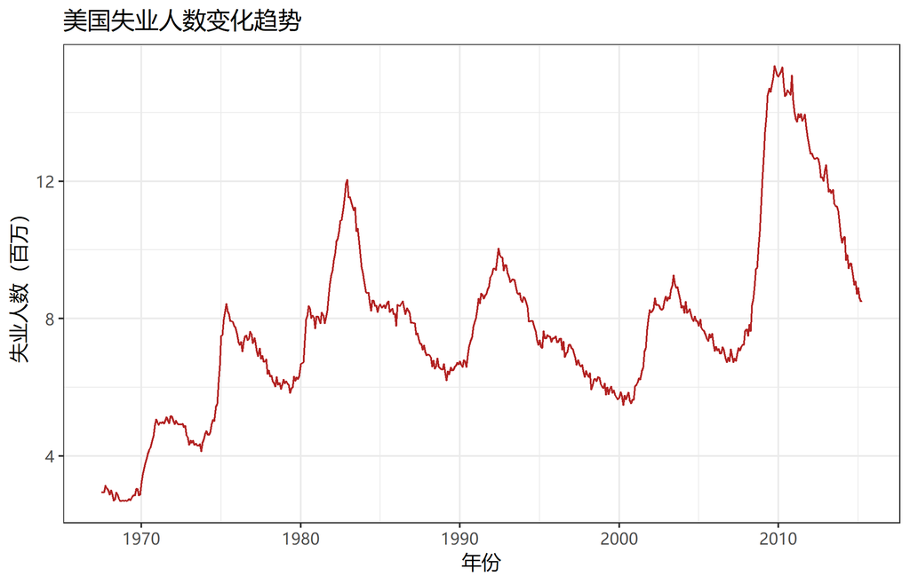

```r
ggplot(economics, aes(date, unemploy / 1000)) +
  geom_line(color = "firebrick") +
  labs(x = "年份", y = "失业人数（百万）",
       title = "美国失业人数变化趋势")
```

## 5.3 平滑曲线 geom_smooth()

为散点图添加拟合曲线，默认带 95% 置信区间：

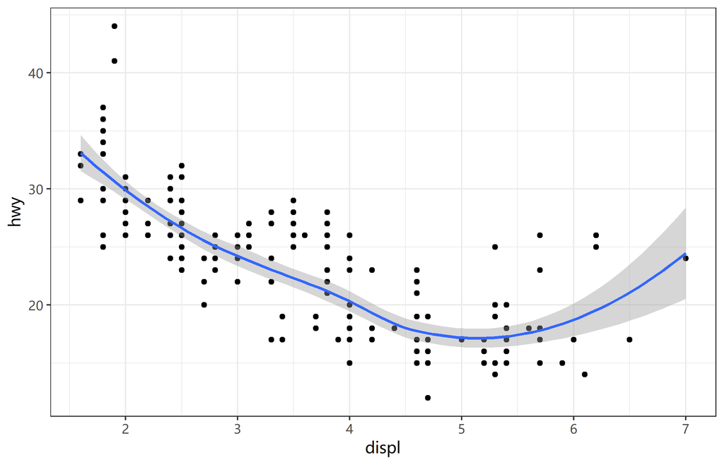

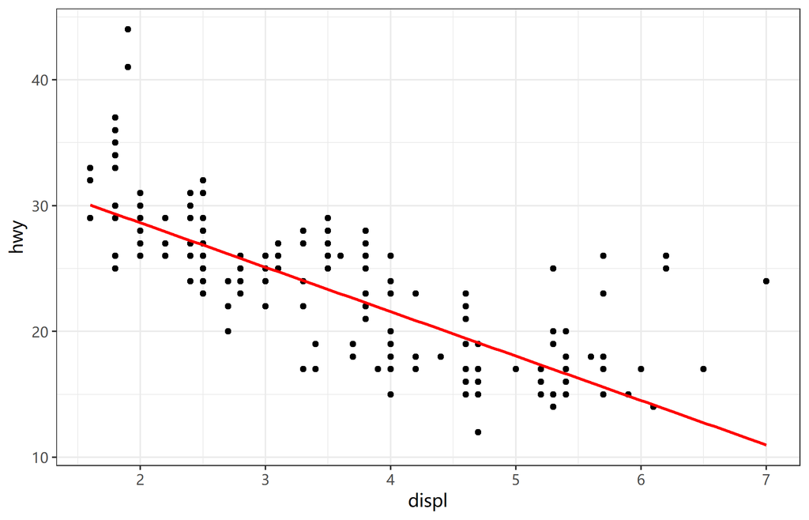

```r
# 默认方法（数据量小时为 loess 局部回归）
ggplot(mpg, aes(displ, hwy)) +
  geom_point() +
  geom_smooth()

# 线性回归 + 去掉置信区间
ggplot(mpg, aes(displ, hwy)) +
  geom_point() +
  geom_smooth(method = "lm", se = FALSE, color = "red")
```

## 5.4 柱状图 geom_bar() 与 geom_col()

- `geom_bar()`：自动统计每组的**频数**（y 轴是 count）；
- `geom_col()`：直接使用数据中的数值作为柱高。

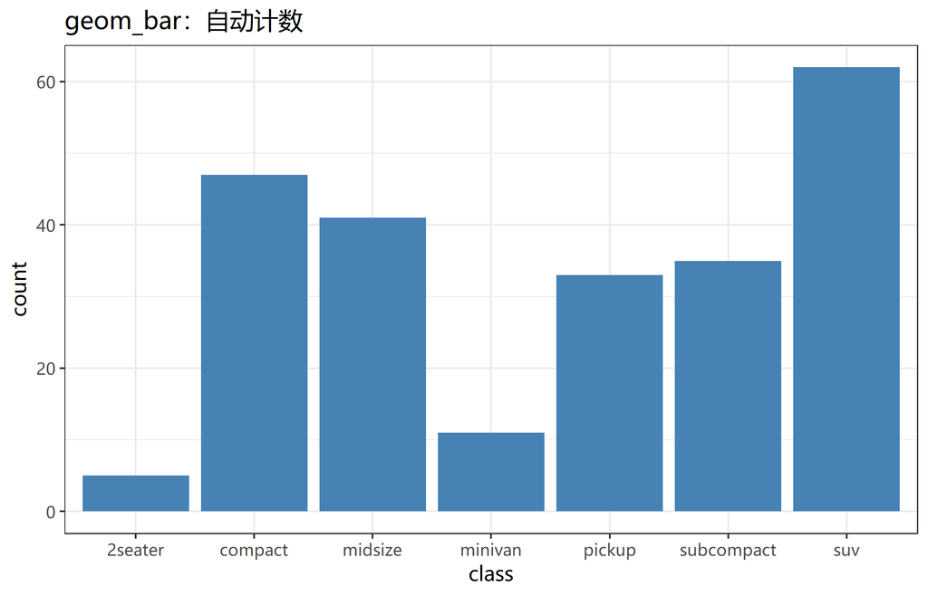

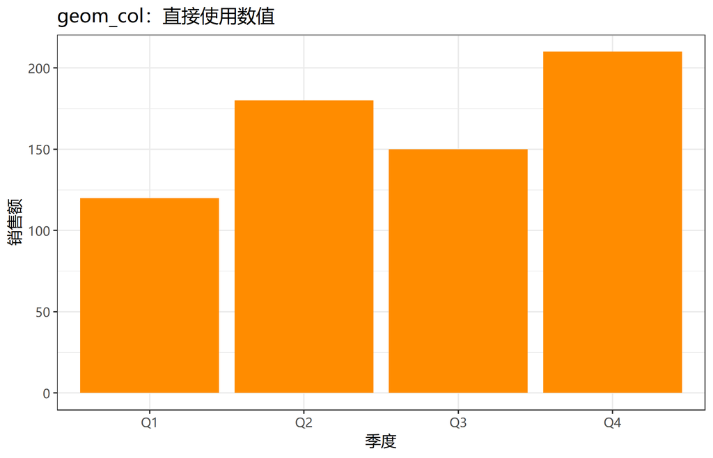

```r
# geom_bar：自动计数
ggplot(mpg, aes(class)) +
  geom_bar(fill = "steelblue") +
  labs(title = "geom_bar：自动计数")

# geom_col：使用已有的数值
df <- data.frame(季度 = c("Q1", "Q2", "Q3", "Q4"),
                 销售额 = c(120, 180, 150, 210))
ggplot(df, aes(季度, 销售额)) +
  geom_col(fill = "darkorange") +
  labs(title = "geom_col：直接使用数值")
```

## 5.5 直方图 geom_histogram() 与密度图 geom_density()

展示单个连续变量的分布：

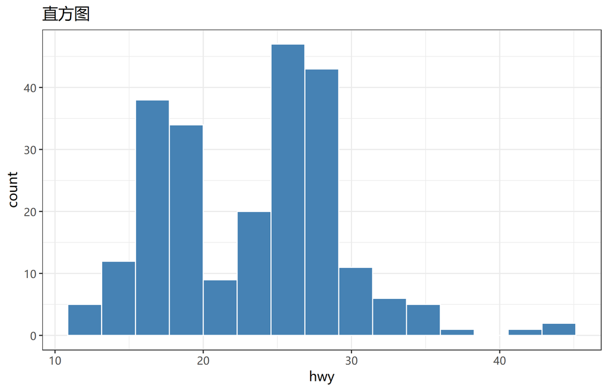

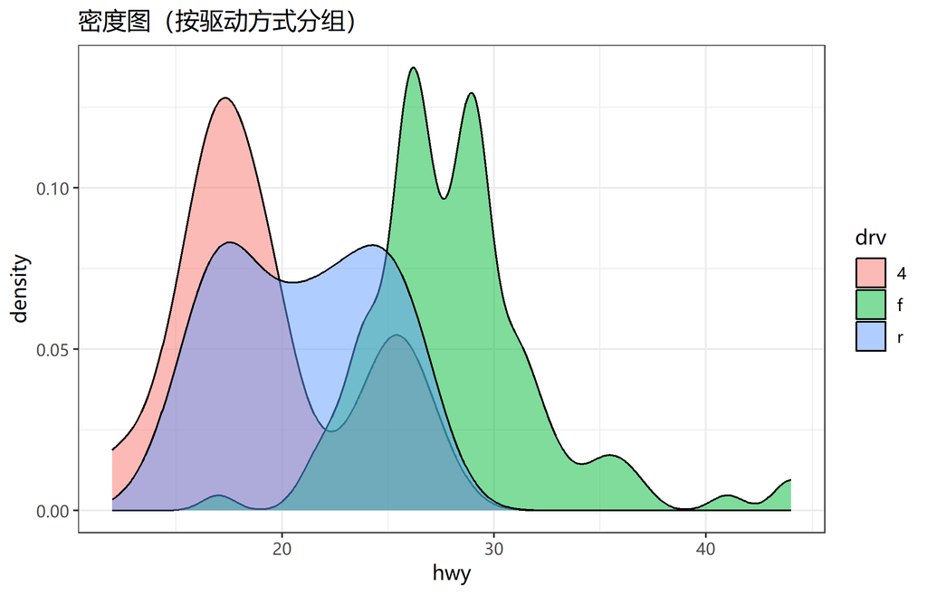

```r
ggplot(mpg, aes(hwy)) +
  geom_histogram(bins = 15, fill = "steelblue", color = "white") +
  labs(title = "直方图")

ggplot(mpg, aes(hwy, fill = drv)) +
  geom_density(alpha = 0.5) +
  labs(title = "密度图（按驱动方式分组）")
```

## 5.6 箱线图 geom_boxplot() 与小提琴图 geom_violin()

比较不同组别的分布：

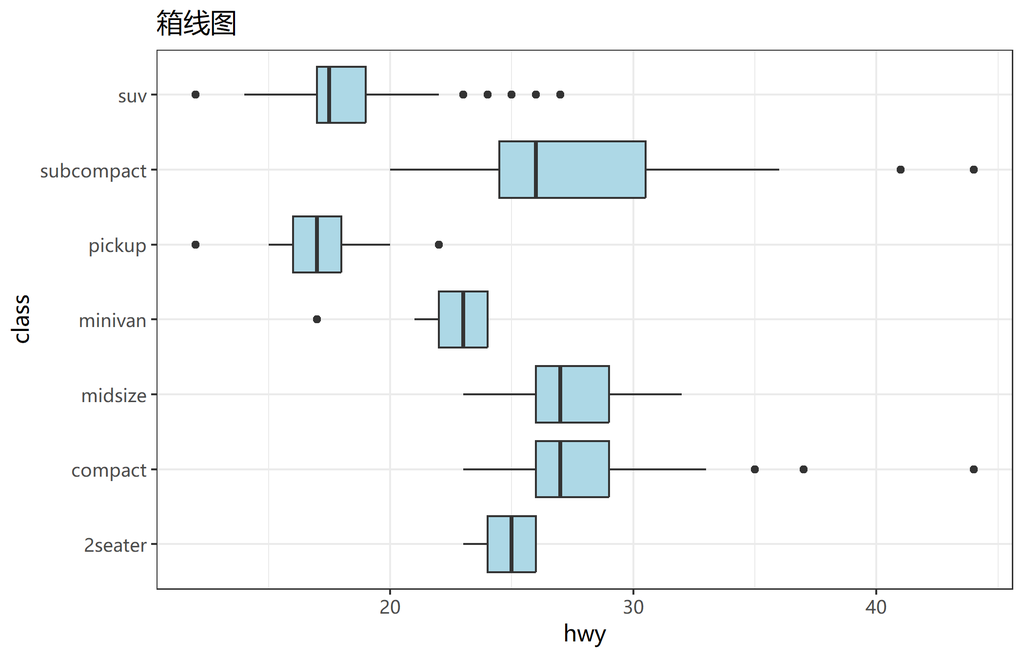

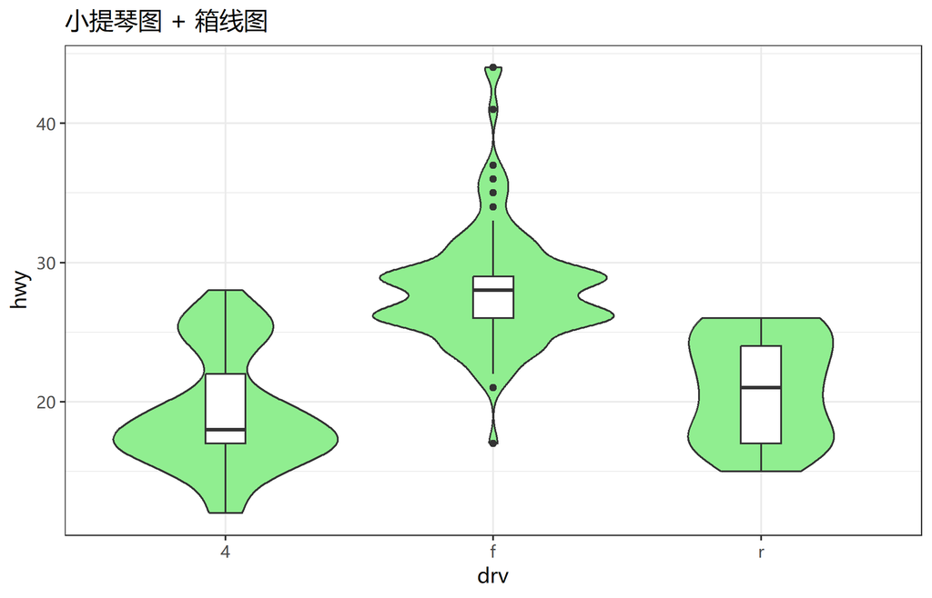

```r
ggplot(mpg, aes(class, hwy)) +
  geom_boxplot(fill = "lightblue") +
  coord_flip() +
  labs(title = "箱线图")

ggplot(mpg, aes(drv, hwy)) +
  geom_violin(fill = "lightgreen") +
  geom_boxplot(width = 0.15, fill = "white") +
  labs(title = "小提琴图 + 箱线图")
```

## 5.7 面积图 geom_area() 与热图 geom_tile()

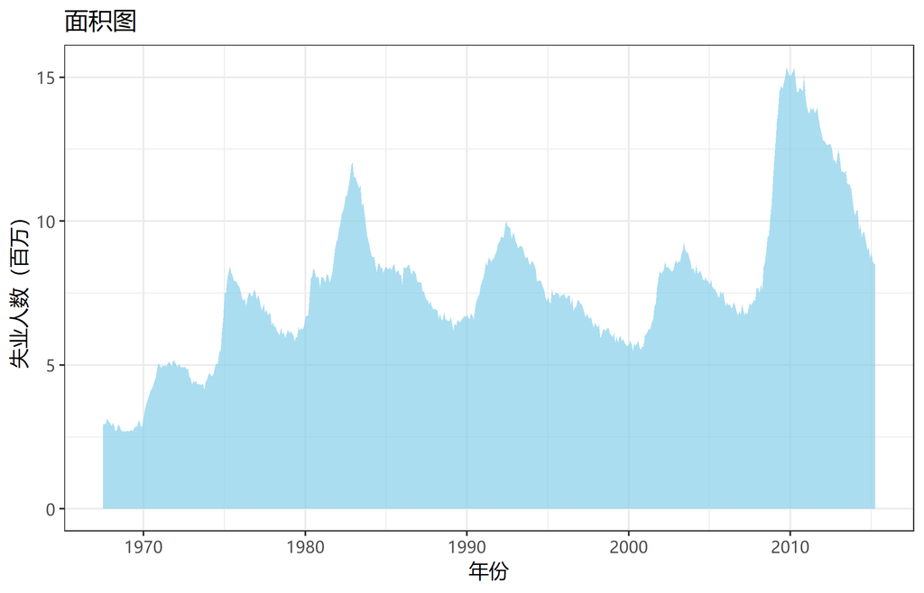

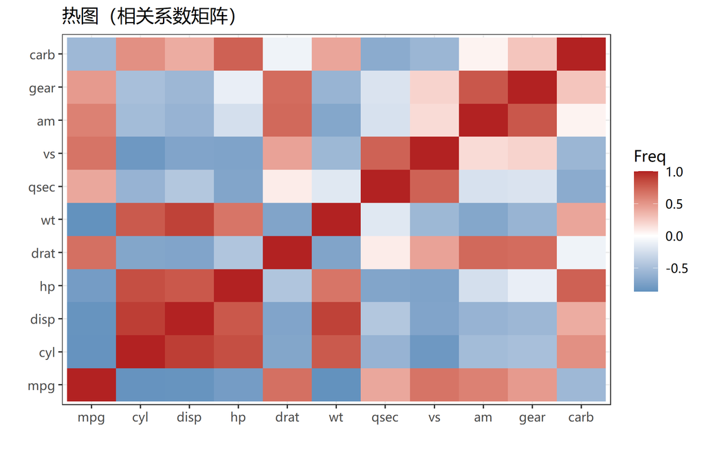

```r
ggplot(economics, aes(date, unemploy / 1000)) +
  geom_area(fill = "skyblue", alpha = 0.7) +
  labs(title = "面积图", x = "年份", y = "失业人数（百万）")

# 相关矩阵热图
cor_mat <- cor(mtcars)
cor_df <- as.data.frame(as.table(cor_mat))
ggplot(cor_df, aes(Var1, Var2, fill = Freq)) +
  geom_tile() +
  scale_fill_gradient2(low = "steelblue", high = "firebrick", mid = "white") +
  labs(title = "热图（相关系数矩阵）", x = "", y = "")
```

## 5.8 常用 geom 速查表

| geom | 图形 | 适用场景 |
| --- | --- | --- |
| `geom_point()` | 散点图 | 两个连续变量的关系 |
| `geom_line()` | 折线图 | 时间序列、趋势 |
| `geom_smooth()` | 平滑曲线 | 拟合关系、趋势 |
| `geom_bar()` | 柱状图（计数） | 分类变量频数 |
| `geom_col()` | 柱状图（数值） | 已汇总的数值 |
| `geom_histogram()` | 直方图 | 连续变量分布 |
| `geom_density()` | 密度图 | 分布形状比较 |
| `geom_boxplot()` | 箱线图 | 分组分布比较 |
| `geom_violin()` | 小提琴图 | 分布密度比较 |
| `geom_area()` | 面积图 | 随时间的累积量 |
| `geom_tile()` | 热图 | 矩阵、网格数据 |
| `geom_text()` / `geom_label()` | 文字标签 | 在图中添加文字 |

# 6 标度 scale_*：精细控制映射

标度函数控制”变量 → 视觉属性”的具体方式。命名规律：`scale_ + 美学属性 + _ + 类型`。

## 6.1 颜色标度

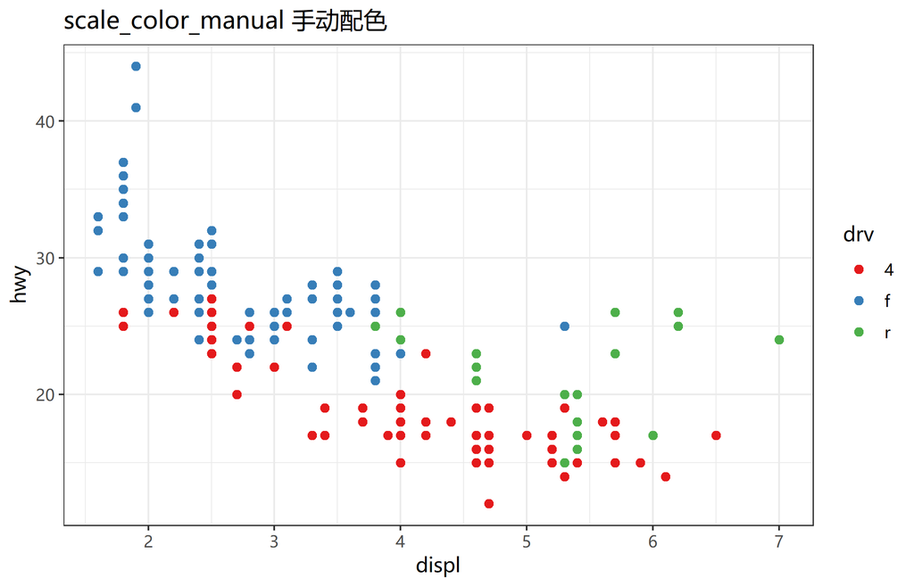

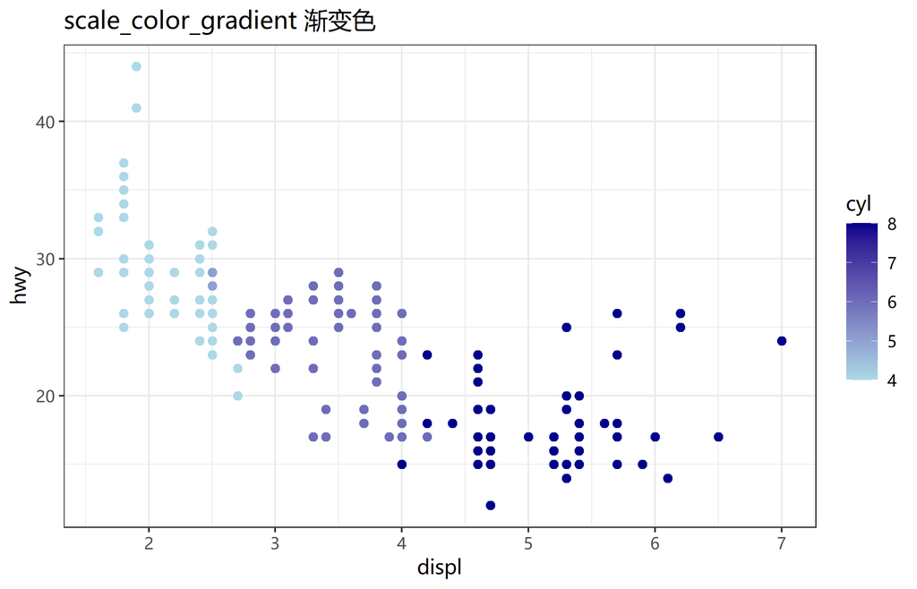

```r
# 离散变量：手动指定颜色
ggplot(mpg, aes(displ, hwy, color = drv)) +
  geom_point(size = 2) +
  scale_color_manual(values = c("4" = "#E41A1C", "f" = "#377EB8", "r" = "#4DAF4A")) +
  labs(title = "scale_color_manual 手动配色")

# 连续变量：渐变色
ggplot(mpg, aes(displ, hwy, color = cyl)) +
  geom_point(size = 2) +
  scale_color_gradient(low = "lightblue", high = "darkblue") +
  labs(title = "scale_color_gradient 渐变色")
```

推荐使用 `scale_color_brewer()` / `scale_fill_brewer()`（ColorBrewer 专业配色）或 `scale_color_viridis_d()`（色盲友好的 viridis 配色）。

## 6.2 坐标轴标度

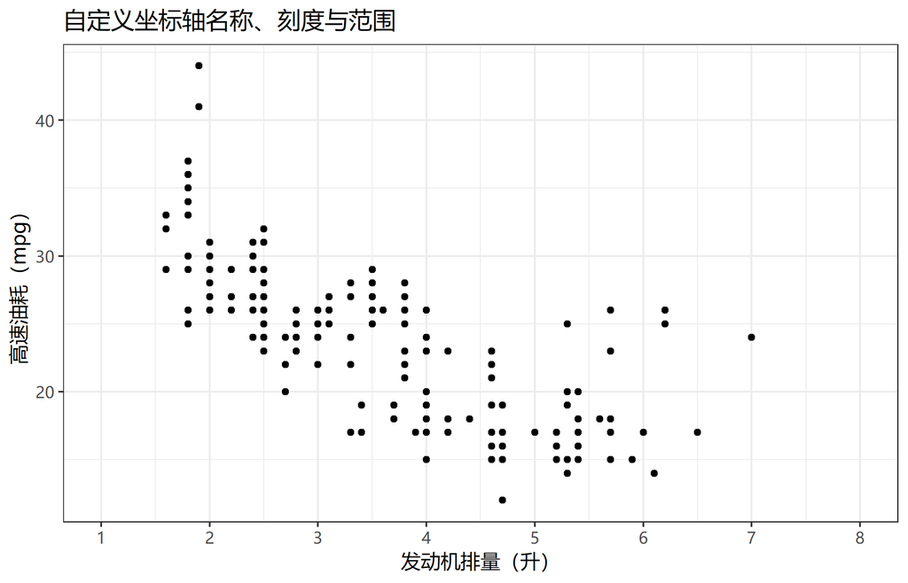

```r
ggplot(mpg, aes(displ, hwy)) +
  geom_point() +
  scale_x_continuous(name = "发动机排量（升）",
                     breaks = seq(0, 8, by = 1),
                     limits = c(1, 8)) +
  scale_y_continuous(name = "高速油耗（mpg）") +
  labs(title = "自定义坐标轴名称、刻度与范围")
```

## 6.3 坐标轴变换

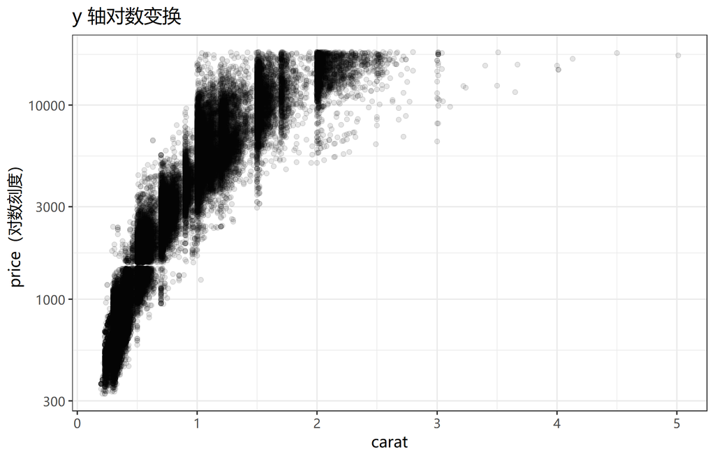

```r
ggplot(diamonds, aes(carat, price)) +
  geom_point(alpha = 0.1) +
  scale_y_log10() +
  labs(title = "y 轴对数变换", y = "price（对数刻度）")
```

# 7 分面 facet：一页多图

分面按分类变量把数据拆成多个子图，是探索分组差异的利器。

## 7.1 facet_wrap()：单变量分面

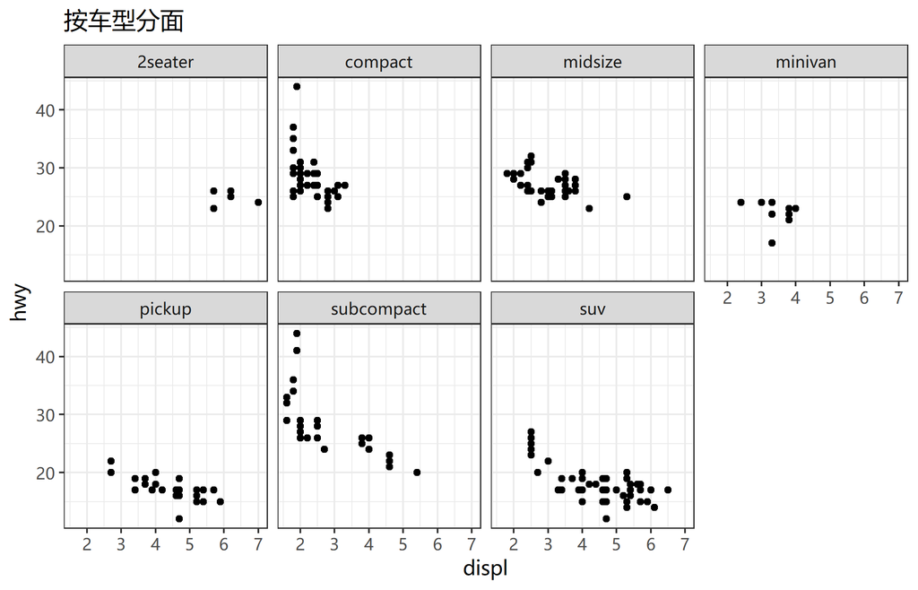

```r
ggplot(mpg, aes(displ, hwy)) +
  geom_point() +
  facet_wrap(~ class, ncol = 4) +
  labs(title = "按车型分面")
```

## 7.2 facet_grid()：双变量网格分面

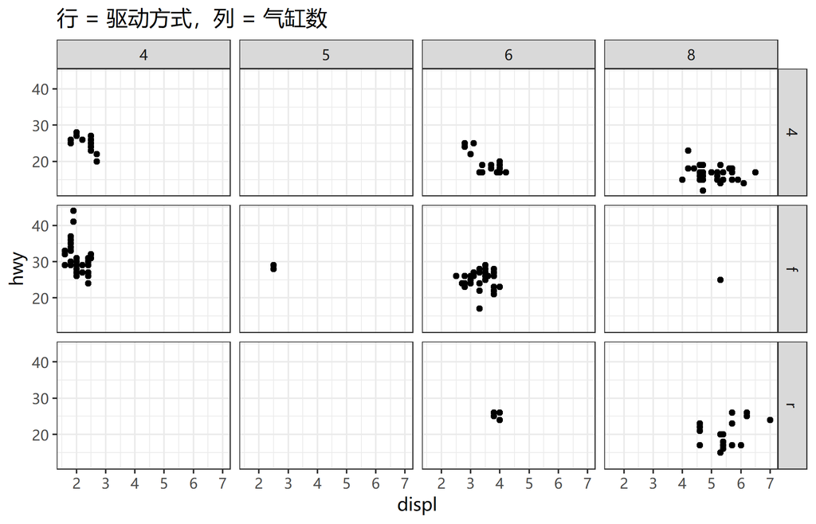

```r
ggplot(mpg, aes(displ, hwy)) +
  geom_point() +
  facet_grid(drv ~ cyl) +
  labs(title = "行 = 驱动方式，列 = 气缸数")
```

# 8 坐标系 coord_*

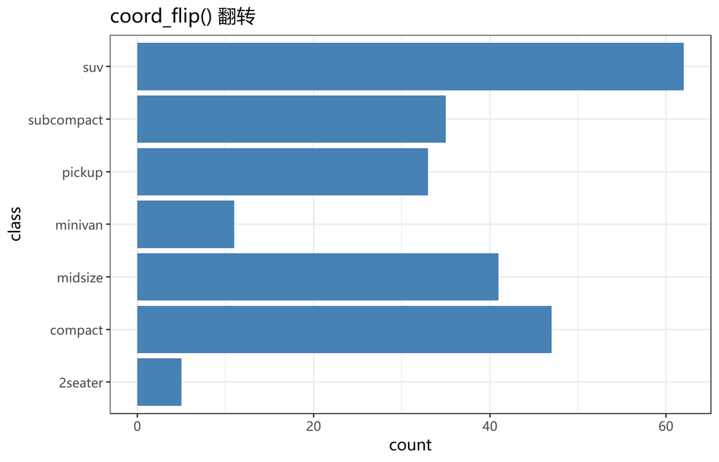

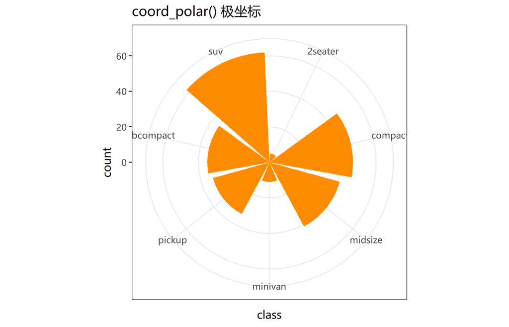

```r
# coord_flip：翻转坐标轴（横向柱状图）
ggplot(mpg, aes(class)) +
  geom_bar(fill = "steelblue") +
  coord_flip() +
  labs(title = "coord_flip() 翻转")

# coord_polar：极坐标（柱状图 → 玫瑰图）
ggplot(mpg, aes(class)) +
  geom_bar(fill = "darkorange") +
  coord_polar() +
  labs(title = "coord_polar() 极坐标")
```

# 9 标题、标签与注释

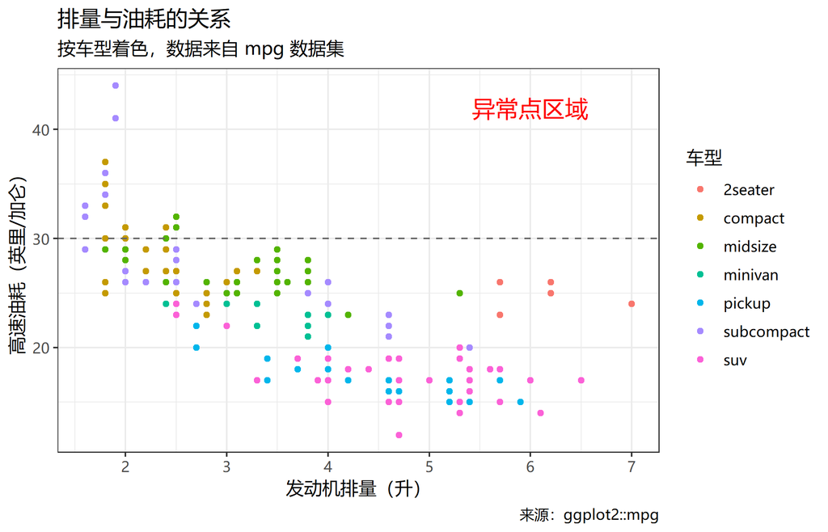

```r
p <- ggplot(mpg, aes(displ, hwy, color = class)) +
  geom_point() +
  labs(
    title = "排量与油耗的关系",
    subtitle = "按车型着色，数据来自 mpg 数据集",
    x = "发动机排量（升）",
    y = "高速油耗（英里/加仑）",
    color = "车型",            # 修改图例标题
    caption = "来源：ggplot2::mpg"
  ) +
  annotate("text", x = 6, y = 42,
           label = "异常点区域", color = "red", size = 5) +
  geom_hline(yintercept = 30, linetype = "dashed", color = "grey40")
p
```

- `labs()`：一站式设置标题、副标题、坐标轴、图例标题、脚注；
- `annotate()`：在指定位置添加注释（text / rect / segment 等）；
- `geom_hline()` / `geom_vline()` / `geom_abline()`：参考线。

# 10 主题 theme：打造专业外观

## 10.1 内置主题

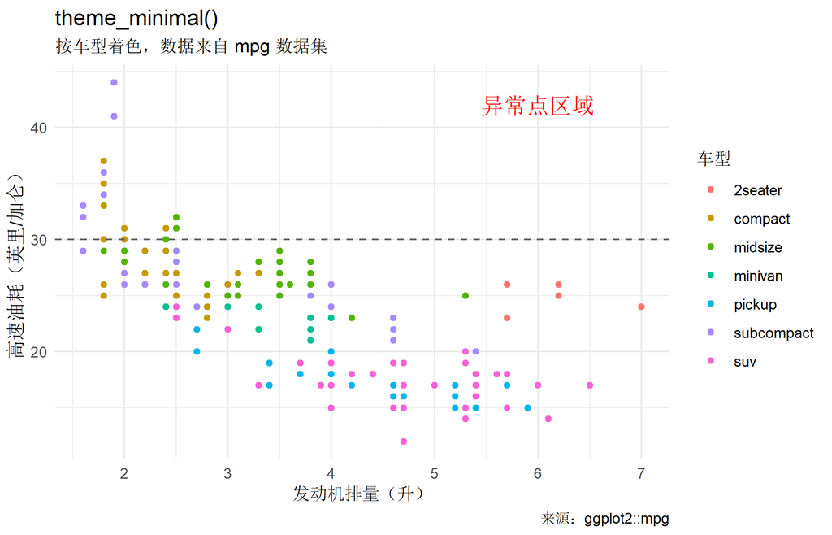

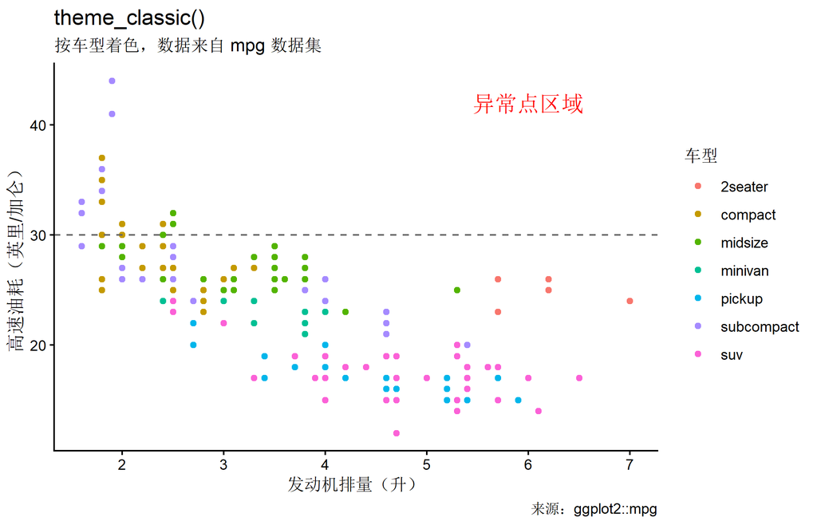

```r
p + theme_minimal() + labs(title = "theme_minimal()")
p + theme_classic() + labs(title = "theme_classic()")
```

常用内置主题：`theme_bw()`、`theme_gray()`（默认）、`theme_minimal()`、`theme_classic()`、`theme_light()`、`theme_dark()`、`theme_void()`。`ggthemes` 包还提供《经济学人》、FiveThirtyEight 等风格。

## 10.2 自定义 theme() 细节

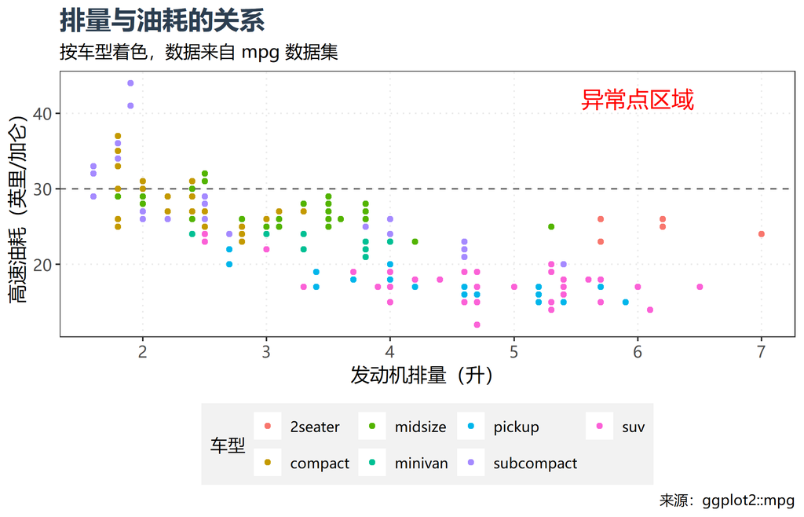

```r
p +
  theme(
    plot.title = element_text(size = 16, face = "bold", color = "#2C3E50"),
    axis.title = element_text(size = 12),
    axis.text = element_text(size = 10, color = "grey30"),
    legend.position = "bottom",                       # 图例放到底部
    legend.background = element_rect(fill = "grey95"),
    panel.grid.minor = element_blank(),               # 去掉次网格线
    panel.grid.major = element_line(linetype = "dotted")
  )
```

`legend.position` 可选 `"top"`、`"bottom"`、`"left"`、`"right"`、`"none"`（隐藏图例）。

# 11 多图组合与保存

## 11.1 保存图片 ggsave()

```r
# 保存最近绘制的一张图
ggsave("my_plot.png", width = 8, height = 5, dpi = 300)

# 保存指定的图，支持 png / pdf / svg / jpg 等格式
ggsave("my_plot.pdf", plot = p, width = 8, height = 5)
```

## 11.2 多图拼接 patchwork

```r
install.packages("patchwork")
library(patchwork)

p1 <- ggplot(mpg, aes(displ, hwy)) + geom_point()
p2 <- ggplot(mpg, aes(class)) + geom_bar()

p1 + p2          # 左右并排
p1 / p2          # 上下堆叠
(p1 | p2) / p2   # 自由组合
```

# 12 综合案例

把前面学到的内容组合起来，完成一张信息丰富的分组图：

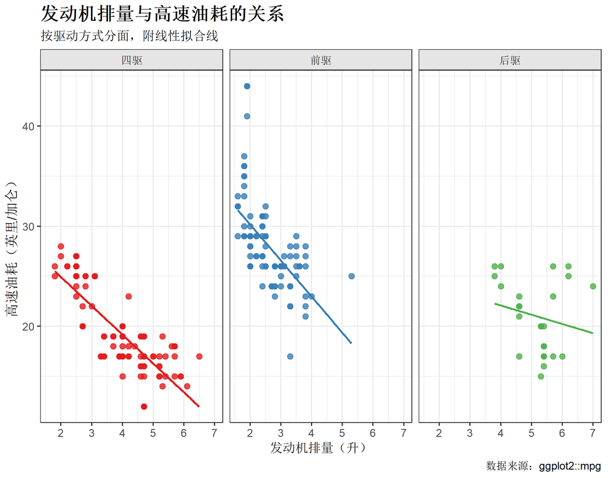

```r
ggplot(mpg, aes(displ, hwy, color = drv)) +
  geom_point(size = 2, alpha = 0.8) +
  geom_smooth(method = "lm", se = FALSE, linewidth = 0.8) +
  facet_wrap(~ drv, labeller = labeller(drv = c(
    "4" = "四驱", "f" = "前驱", "r" = "后驱"))) +
  scale_color_manual(values = c("4" = "#E41A1C",
                                "f" = "#377EB8",
                                "r" = "#4DAF4A")) +
  labs(
    title = "发动机排量与高速油耗的关系",
    subtitle = "按驱动方式分面，附线性拟合线",
    x = "发动机排量（升）",
    y = "高速油耗（英里/加仑）",
    caption = "数据来源：ggplot2::mpg"
  ) +
  theme_bw() +
  theme(
    plot.title = element_text(face = "bold", size = 15),
    strip.background = element_rect(fill = "grey90"),
    legend.position = "none"
  )
```

这张图用到了：散点图层 + 拟合线图层、颜色映射与手动配色、分面与中文分面标签、标题标签、主题微调——正是图形语法”分层叠加”思想的完整体现。

# 13 常见技巧与避坑指南

1. **用 `+` 连接图层**，不要混用管道 `%>%`；`+` 必须放在行尾。
2. **映射 vs 固定值**：按变量变化放 `aes()` 内，统一设定放 `aes()` 外。
3. **`geom_bar()` vs `geom_col()`**：要数频数用前者，数据已有数值用后者。
4. **因子决定顺序**：柱状图、箱线图的顺序由因子水平决定，可用 `factor(x, levels = ...)` 或 `forcats::fct_reorder()` 调整。
5. **分组不显式**：折线图按组连线时，指定 `aes(group = 分组变量)`。
6. **重叠点太多**：用 `alpha` 透明度、`geom_jitter()` 抖动或 `geom_hex()` 二维分箱。
7. **去掉图例**：`theme(legend.position = "none")` 或 `guides(color = "none")`。
8. **中文乱码（Windows）**：先注册字体再使用，例如 `windowsFonts(yahei = windowsFont("Microsoft YaHei"))` 后设置 `theme_set(theme_bw(base_family = "yahei"))`；或使用 `showtext` 包获得跨平台一致的字体效果。

# 14 进阶资源

- 官方文档：https://ggplot2.tidyverse.org
- 《ggplot2: Elegant Graphics for Data Analysis》（Hadley Wickham，第 3 版，免费在线阅读）
- 《R for Data Science》可视化章节：https://r4ds.hadley.nz
- R Graph Gallery：https://r-graph-gallery.com（大量可直接套用的图例代码）
- 扩展包索引：https://exts.ggplot2.tidyverse.org

*本文档由 R Markdown 生成，所有代码均可直接运行复现。*

*[点击下载 PDF版本](https://bio2025.site/study/files/ggplot2_tutorial.pdf)*